## Vulnerability Assessment for Black-throated Green Warbler

The total population for Black-throated Green Warbler in Bird Conservation Region 6 South (BCR 6s; Boreal Taiga Plains South), according to estimates from the Boreal Avian Modelling Centre, is 829,686. Approximately 17.94% of the population occurs within the OSR, giving a BCR-level exposure index of 0.84 This means the OSR population is 0.84 times lower than would be expected given the proportion of the BCR covered by the OSR.

The estimated reference populations size for Black-throated Green Warbler in the OSR, according to Alberta Biodiversity Monitoring Institute (ABMI) model predictions is 451,836. Reference population size refers to the expected population size under an assumption of no human development. The current population size with human development is 297,053.

The total exposure to oil sands disturbance for Black-throated Green Warbler throughout the OSR, calculated as the sum of the percentage of the species’ reference population within each grid cell multiplied by the percentage of each grid cell covered by oil sands disturbance is 283. The percentile rank of total exposure, among all bird species modeled is 0.816. The percentile rank of exposure for Black-throated Green Warbler within all lease areas is 0.847.

#### Sensitivity to energy-sector disturbances

Sensitivity scores area derived from the Sector Effects and Linear Features effects reported by the Alberta Biodiversity Monitoring Institute (ABMI; https://abmi.ca/data-portal/32.html).

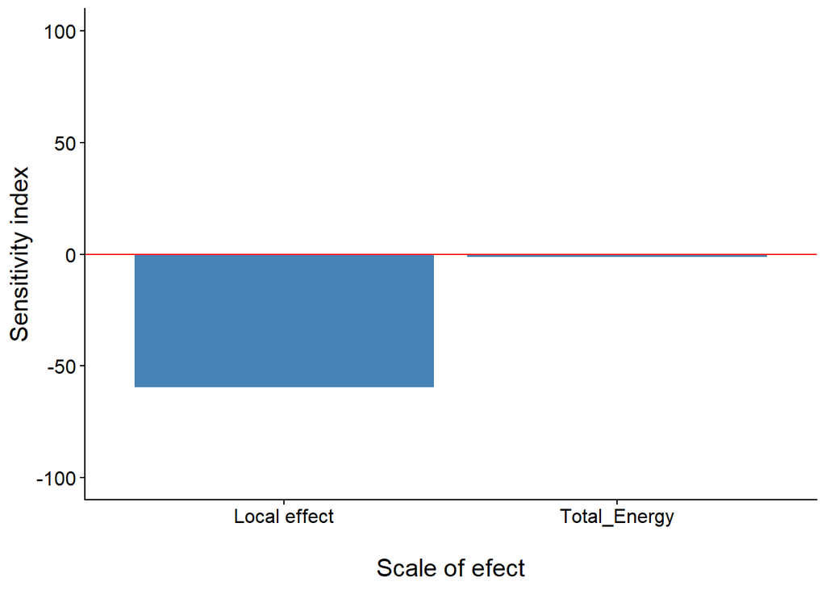

**Figure 1.** Sensitivity to energy sector disturbance at the local extent. ____________________________________________________________________________________________ ____________________________________________________________________________________________

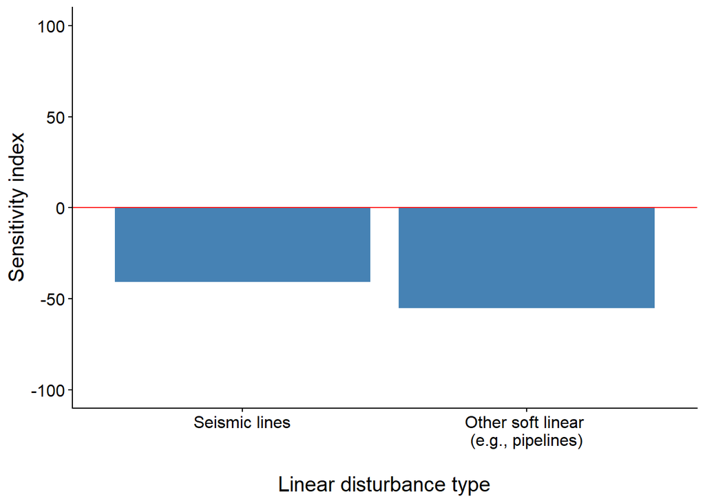

**Figure 2.** Sensitivity to seismic lines and other soft linear disturbances at the local extent.

#### Reference exposure

Reference exposure refers to the proportion of the population that would be exposed to oil sands disturbance under a ‘reference population’ scenario. The reference population is the predicted population distribution if there was no human disturbance. As such, this is the proportion of the ‘undisturbed’ population being exposed to oil sands disturbances.

Table 1. Reference exposure information for the selected species, oil sands area, and lease holder in the Oil Sands Region of Alberta, Canada. Reference exposure refers to the exposure of the estimated population that would have existed with no human disturbance.

| Species name | Oil Sands Area | Lease holder | Lease number | Lease areaa (ha) | Lease population | Exposure index† |
| --- | --- | --- | --- | --- | --- | --- |
| Black-throated Green Warbler | Athabasca | Canadian Natural Resources Limited | 10097AAAA | 17 723.4 | 305.0 | 0.7 |
| Black-throated Green Warbler | Athabasca | Canadian Natural Resources Limited | 10147G | 1 045.2 | 16.0 | 0.6 |
| Black-throated Green Warbler | Athabasca | Canadian Natural Resources Limited | 10423GG | 26 981.5 | 756.0 | 1.1 |
| Black-throated Green Warbler | Athabasca | Canadian Natural Resources Limited | 10787T | 14 574.6 | 229.0 | 0.6 |
| Black-throated Green Warbler | Athabasca | Canadian Natural Resources Limited | 10787T | 14 574.6 | 229.0 | 0.6 |
| Black-throated Green Warbler | Athabasca | Canadian Natural Resources Limited | 11337M | 264.6 | 2.0 | 0.3 |
| Black-throated Green Warbler | Athabasca | Canadian Natural Resources Limited | 11469E | 165.2 | 4.0 | 1.0 |
| Black-throated Green Warbler | Athabasca | Canadian Natural Resources Limited | 11472B | 10 771.2 | 109.0 | 0.4 |
| Black-throated Green Warbler | Athabasca | Canadian Natural Resources Limited | 11472B | 807.0 | 109.0 | 5.4 |
| Black-throated Green Warbler | Athabasca | Canadian Natural Resources Limited | 11475QQQ | 43 423.4 | 584.0 | 0.5 |
| Black-throated Green Warbler | Athabasca | Canadian Natural Resources Limited | 11480B | 27 624.8 | 682.0 | 1.0 |
| Black-throated Green Warbler | Athabasca | Canadian Natural Resources Limited | 11509K | 530.1 | 3.0 | 0.2 |
| Black-throated Green Warbler | Athabasca | Canadian Natural Resources Limited | 11676B | 24 241.8 | 4 129.0 | 6.8 |
| Black-throated Green Warbler | Athabasca | Canadian Natural Resources Limited | 11965D | 50 802.5 | 2 358.0 | 1.8 |
| Black-throated Green Warbler | Athabasca | Canadian Natural Resources Limited | 12052 | 4 744.5 | 99.0 | 0.8 |
| Black-throated Green Warbler | Athabasca | Canadian Natural Resources Limited | 12087C | 1 578.3 | 5.0 | 0.1 |
| Black-throated Green Warbler | Athabasca | Canadian Natural Resources Limited | 12190B | 25 303.9 | 568.0 | 0.9 |
| Black-throated Green Warbler | Athabasca | Canadian Natural Resources Limited | 12301G | 15 788.8 | 206.0 | 0.5 |
| Black-throated Green Warbler | Athabasca | Canadian Natural Resources Limited | 12580F | 4 055.5 | 380.0 | 3.7 |
| Black-throated Green Warbler | Athabasca | Canadian Natural Resources Limited | 13485 | 12 119.2 | 178.0 | 0.6 |
| Black-throated Green Warbler | Athabasca | Canadian Natural Resources Limited | 6619CC | 3 081.4 | 55.0 | 0.7 |
| Black-throated Green Warbler | Athabasca | Canadian Natural Resources Limited | 8993E | 5 003.8 | 43.0 | 0.3 |
| Black-throated Green Warbler | Athabasca | Canadian Natural Resources Limited | 9272F | 1 656.7 | 30.0 | 0.7 |
| Black-throated Green Warbler | Athabasca | Canadian Natural Resources Limited | 9403J | 22 361.9 | 274.0 | 0.5 |
| Black-throated Green Warbler | Athabasca | Canadian Natural Resources Limited | 9404Z | 38 434.7 | 608.0 | 0.6 |
| Black-throated Green Warbler | Athabasca | Canadian Natural Resources Limited | 9466DD | 72 308.2 | 2 119.0 | 1.2 |
| Black-throated Green Warbler | Athabasca | Canadian Natural Resources Limited | 9673Q | 14 950.0 | 59.0 | 0.2 |
| Black-throated Green Warbler | Athabasca | Canadian Natural Resources Limited | 9884F | 1 648.2 | 10.0 | 0.2 |

†The observed proportion of the OSR population in the lease area divided by the proportion of the OSR occupied by the lease area

[interactive chart not shown]

**Figure 3.** Interactive map showing the reference distribution and exposure metrics for Black-throated Green Warbler on the selected lease areas. Reference distribution refers to the estimated population that would have existed with no human disturbance.

#### Current exposure

Current exposure refers to the proportion of the current population being exposed to oil sands disturbance. The current population is the predicted population distribution under current levels of human disturbance.

Table 2. Current exposure information for the selected species, oil sands area, and lease holder in the Oil Sands Region of Alberta, Canada.

| Species name | Oil Sands Area | Lease holder | Lease number | Lease areaa (ha) | Lease population | Exposure index† |
| --- | --- | --- | --- | --- | --- | --- |
| Black-throated Green Warbler | Athabasca | Canadian Natural Resources Limited | 10097AAAA | 17 723.4 | 265.0 | 0.9 |
| Black-throated Green Warbler | Athabasca | Canadian Natural Resources Limited | 10147G | 1 045.2 | 13.0 | 0.8 |
| Black-throated Green Warbler | Athabasca | Canadian Natural Resources Limited | 10423GG | 26 981.5 | 618.0 | 1.4 |
| Black-throated Green Warbler | Athabasca | Canadian Natural Resources Limited | 10787T | 14 574.6 | 179.0 | 0.7 |
| Black-throated Green Warbler | Athabasca | Canadian Natural Resources Limited | 10787T | 14 574.6 | 179.0 | 0.7 |
| Black-throated Green Warbler | Athabasca | Canadian Natural Resources Limited | 11337M | 264.6 | 1.0 | 0.2 |
| Black-throated Green Warbler | Athabasca | Canadian Natural Resources Limited | 11469E | 165.2 | 4.0 | 1.5 |
| Black-throated Green Warbler | Athabasca | Canadian Natural Resources Limited | 11472B | 10 771.2 | 94.0 | 0.5 |
| Black-throated Green Warbler | Athabasca | Canadian Natural Resources Limited | 11472B | 807.0 | 94.0 | 7.0 |
| Black-throated Green Warbler | Athabasca | Canadian Natural Resources Limited | 11475QQQ | 43 423.4 | 503.0 | 0.7 |
| Black-throated Green Warbler | Athabasca | Canadian Natural Resources Limited | 11480B | 27 624.8 | 497.0 | 1.1 |
| Black-throated Green Warbler | Athabasca | Canadian Natural Resources Limited | 11509K | 530.1 | 3.0 | 0.3 |
| Black-throated Green Warbler | Athabasca | Canadian Natural Resources Limited | 11676B | 24 241.8 | 2 089.0 | 5.2 |
| Black-throated Green Warbler | Athabasca | Canadian Natural Resources Limited | 11965D | 50 802.5 | 1 478.0 | 1.8 |
| Black-throated Green Warbler | Athabasca | Canadian Natural Resources Limited | 12052 | 4 744.5 | 94.0 | 1.2 |
| Black-throated Green Warbler | Athabasca | Canadian Natural Resources Limited | 12087C | 1 578.3 | 4.0 | 0.2 |
| Black-throated Green Warbler | Athabasca | Canadian Natural Resources Limited | 12190B | 25 303.9 | 439.0 | 1.0 |
| Black-throated Green Warbler | Athabasca | Canadian Natural Resources Limited | 12301G | 15 788.8 | 183.0 | 0.7 |
| Black-throated Green Warbler | Athabasca | Canadian Natural Resources Limited | 12580F | 4 055.5 | 257.0 | 3.8 |
| Black-throated Green Warbler | Athabasca | Canadian Natural Resources Limited | 13485 | 12 119.2 | 155.0 | 0.8 |
| Black-throated Green Warbler | Athabasca | Canadian Natural Resources Limited | 6619CC | 3 081.4 | 52.0 | 1.0 |
| Black-throated Green Warbler | Athabasca | Canadian Natural Resources Limited | 8993E | 5 003.8 | 39.0 | 0.5 |
| Black-throated Green Warbler | Athabasca | Canadian Natural Resources Limited | 9272F | 1 656.7 | 22.0 | 0.8 |
| Black-throated Green Warbler | Athabasca | Canadian Natural Resources Limited | 9403J | 22 361.9 | 245.0 | 0.7 |
| Black-throated Green Warbler | Athabasca | Canadian Natural Resources Limited | 9404Z | 38 434.7 | 536.0 | 0.8 |
| Black-throated Green Warbler | Athabasca | Canadian Natural Resources Limited | 9466DD | 72 308.2 | 1 834.0 | 1.5 |
| Black-throated Green Warbler | Athabasca | Canadian Natural Resources Limited | 9673Q | 14 950.0 | 59.0 | 0.2 |
| Black-throated Green Warbler | Athabasca | Canadian Natural Resources Limited | 9884F | 1 648.2 | 10.0 | 0.4 |

†The observed proportion of the OSR population in the lease area divided by the proportion of the OSR occupied by the lease area

[interactive chart not shown]

**Figure 4.** Interactive map showing the current distribution and exposure metrics for Black-throated Green Warbler on the selected lease areas.

#### Cell-level Exposure

Cell-level exposure for Black-throated Green Warbler within the selected lease areas is calculated as the sum of exposure in all 1 km<sup>2</sup> grid cells within each lease area. Because lease areas vary widely in size, we also calculated relative exposure as the lease area exposure divided by the quotient of total lease area divided by the total species exposure among all lease areas. This relative exposure metric gives the lease area exposure adjusted to account for the size of the lease and the species-specific exposure among all leases.

Table 3. Cell-level exposure information for the selected species, oil sands area, and lease holder in the Oil Sands Region of Alberta, Canada.

| CommonName | Oil Sands Area | Lease holder | Lease number | Lease-level exposure | Relative lease exposure† |
| --- | --- | --- | --- | --- | --- |
| Black-throated Green Warbler | Athabasca | Canadian Natural Resources Limited | 12052 | 0.072 | 0.122 |
| Black-throated Green Warbler | Athabasca | Canadian Natural Resources Limited | 11472B | 0.137 | 0.103 |
| Black-throated Green Warbler | Athabasca | Canadian Natural Resources Limited | 11472B | 0.007 | 0.070 |
| Black-throated Green Warbler | Athabasca | Canadian Natural Resources Limited | 9884F | 0.006 | 0.032 |
| Black-throated Green Warbler | Athabasca | Canadian Natural Resources Limited | 10147G | 0.025 | 0.191 |
| Black-throated Green Warbler | Athabasca | Canadian Natural Resources Limited | 12190B | 0.476 | 0.152 |
| Black-throated Green Warbler | Athabasca | Canadian Natural Resources Limited | 9673Q | 0.047 | 0.026 |
| Black-throated Green Warbler | Athabasca | Canadian Natural Resources Limited | 9272F | 0.065 | 0.316 |
| Black-throated Green Warbler | Athabasca | Canadian Natural Resources Limited | 11509K | 0.006 | 0.099 |
| Black-throated Green Warbler | Athabasca | Canadian Natural Resources Limited | 8993E | 0.033 | 0.053 |
| Black-throated Green Warbler | Athabasca | Canadian Natural Resources Limited | 11337M | 0.004 | 0.108 |
| Black-throated Green Warbler | Athabasca | Canadian Natural Resources Limited | 12087C | 0.008 | 0.040 |
| Black-throated Green Warbler | Athabasca | Canadian Natural Resources Limited | 11480B | 0.374 | 0.109 |
| Black-throated Green Warbler | Athabasca | Canadian Natural Resources Limited | 11469E | 0.009 | 0.449 |
| Black-throated Green Warbler | Athabasca | Canadian Natural Resources Limited | 11965D | 1.116 | 0.178 |
| Black-throated Green Warbler | Athabasca | Canadian Natural Resources Limited | 11676B | 1.670 | 0.557 |
| Black-throated Green Warbler | Athabasca | Canadian Natural Resources Limited | 11475QQQ | 0.645 | 0.120 |
| Black-throated Green Warbler | Athabasca | Canadian Natural Resources Limited | 6619CC | 0.017 | 0.045 |
| Black-throated Green Warbler | Athabasca | Canadian Natural Resources Limited | 10787T | 0.216 | 0.120 |
| Black-throated Green Warbler | Athabasca | Canadian Natural Resources Limited | 13485 | 0.238 | 0.159 |
| Black-throated Green Warbler | Athabasca | Canadian Natural Resources Limited | 9404Z | 0.517 | 0.109 |
| Black-throated Green Warbler | Athabasca | Canadian Natural Resources Limited | 10097AAAA | 0.435 | 0.199 |
| Black-throated Green Warbler | Athabasca | Canadian Natural Resources Limited | 10423GG | 0.594 | 0.178 |
| Black-throated Green Warbler | Athabasca | Canadian Natural Resources Limited | 9403J | 0.133 | 0.048 |
| Black-throated Green Warbler | Athabasca | Canadian Natural Resources Limited | 12580F | 0.324 | 0.646 |
| Black-throated Green Warbler | Athabasca | Canadian Natural Resources Limited | 12301G | 0.391 | 0.200 |
| Black-throated Green Warbler | Athabasca | Canadian Natural Resources Limited | 10787T | 0.216 | 0.120 |
| Black-throated Green Warbler | Athabasca | Canadian Natural Resources Limited | 9466DD | 0.886 | 0.099 |

†The sum of cell-level exposure within the lease divided by the quotient of cell area in square km and the sum of the species exposure among all leases.

[interactive chart not shown]